# 功能建模

## 1. 功能建模 - 系统顺序图与操作契约

**1.1 什么是功能建模？**

给出系统面向外部实体（用户及外部系统）要实现的 **业务操作** 功能的定义

**1.2 为什么要进行功能建模**

1. 识别所有系统要提供的业务操作，给出严格的定义
2. 通过识别这些操作，精确的估算工作量
3. 完善系统实现的细节（消息、参数）等，进一步完善领域模型与资源API设计

建模方法与工具：

- 系统顺序图（System Sequence Diagram）
- 操作协议（Operation contracts）
- 基于功能点的项目工作量估计（Function Points）

**1.3 系统实训图案例**

微信OAuth2.0授权登录:

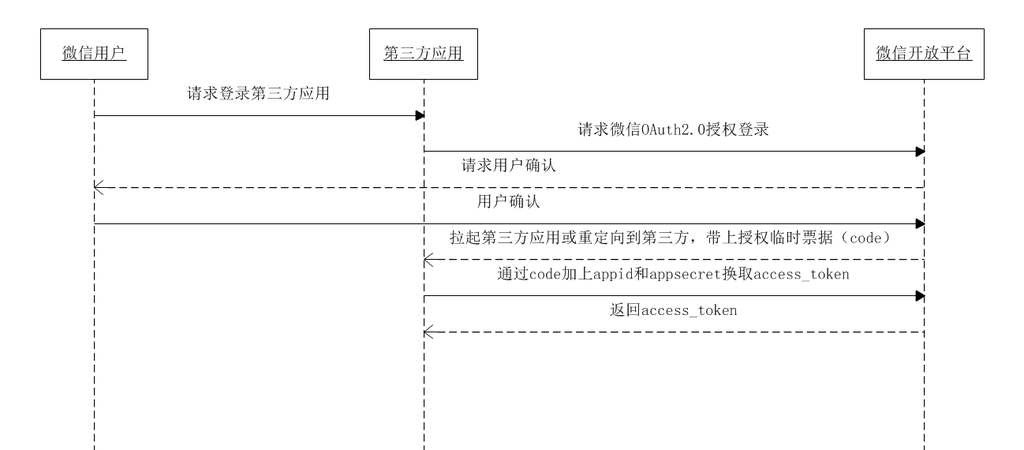

微信小程序开放接口（login）工作原理：

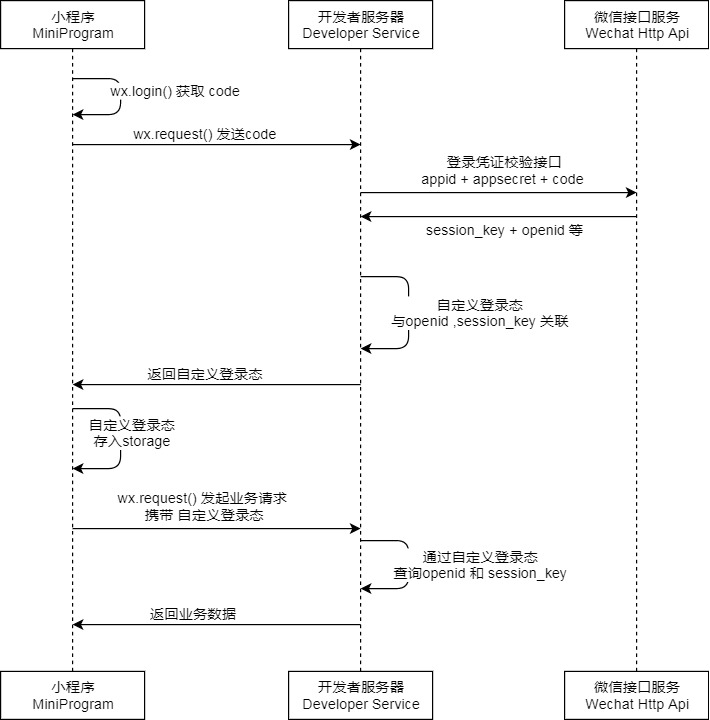

**注意，我们不能获得用户微信号等敏感信息，只是微信 api 为你 appId 生成的 OpenID。 [详细说明](https://developers.weixin.qq.com/miniprogram/dev/api/open.html#wxgetuserinfoobject)

这个图描述了系统之间协作的过程

**1.4 功能点（FP）**

[Introduction to Function Points](http://www.ifpug.org/Conference%20Proceedings/IFPUG-2004/IFPUG2004-04-Aguiar-introduction-to-function-point-analysis.pdf) - IFPUG

## 2、需求分析全过程

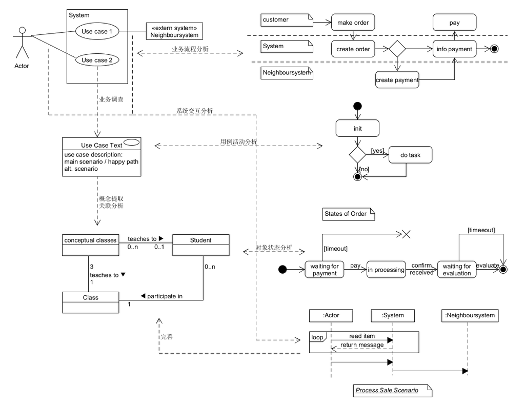

## 3、团队作业

- 1、About（项目规划）
- 2、Team profile（团队组建）
- 3、Investigation（项目前期调研）
- 4、Vision（项目愿景）
- 5、Product Backlog （产品特性）
- 6、Requirement specification（需求规格说明）
  - 6.1 Usecase Diagram（用例图）
  - 6.2 Use Cases（用例+活动图）
  - 6.3 Domian Model（领域模型）
  - 6.4 State Model（状态模型）
  - **6.5 System Sequence Diagram（功能模型）**
- 7、Design（设计）
  - 7.1 UI design
    - XX 用例 UI设计
  - 7.2 Database design
    - 7.2.1 用户及权限系统数据库设计
    - 7.2.2 XX子系统数据课设计
    - 7.2.x 第三方数据评审结果
  - **7.3 API 设计**
- 8、生产规范与指南
  - 8.1 XX 代码规范
  - 8.2 REST API 设计规范
- X1 meet_recording
  - inception meeting (yy/mm/dd)
  - **Iteration X meeting (yy/mm/dd)**
- X2 Tech/Work Report
  - 学号-title
- XX **建模练习**
  - XX1 XX应用
  - XX2 建模要求
  - XX3 建模者答案与评价

团队作业要求：

1. 6.5 系统顺序图
   - 每个成员至少编写一个应用场景的系统顺序图（左用户，中间是系统，右边是外部实体对象）
   - 至少一个操作需要写后置条件，用注释符号表示
   - 请使用自己 git 账号体完成该任务（同时在文字中标明自己的学号）
2. 7.3 给出部分正式的 API 说明书
   - 建议参考 [微信开发平台](https://open.weixin.qq.com/cgi-bin/showdocument?action=dir_list&t=resource/res_list&verify=1&id=open1419317851&token=&lang=zh_CN) 或 [微信支付API](https://pay.weixin.qq.com/wiki/doc/api/app/app.php?chapter=9_1)
   - 部分应用场景的核心 API 必须给出代码实例
   - 部分复杂应用场景的核心 API，给出系统顺序图
3. XX 建模练习 要求：
   - 练习文档编写
     - 选择一个你喜欢的 移动App 或 其中某业务
     - 参考 Asg_RH 文档格式 编写软件描述
     - 文档要包含一个业务的完整过程
   - 建模要求包括（用例图、XX业务或用例的活动图、XX领域模型、XX对象的状态图、XX场景的系统顺序图与操作协议）
   - 建模者答案：
     - 收集建模者答案URL
     - 建模者不能是本团队成员（至少有一个答案）
     - 给建模者给出评价与建议

团队作业改进要求（ **否则不给评分** ）：

1. [参考结果](https://sysu-sasd-project.github.io/dashboard/) , 具体步骤
   - 创建组织，添加成员，dashboard 空间
   - 在 dashboard 中创建 gh-pages 分支
   - 选择 slate 主题，并按 参考 git 内容修改 _config.yml
   - 将 Git Pages 的地址发给 TA，以方便老师、助理阅读你的作业
   - **偷懒就 fork 它**
2. 修改 about 和 team profile
   - 添加你认为合适的内容，做的更有条理和美观
   - 注意隐私保护，不要透露个人姓名等信息，平时就有昵称即可（作业涉及需要每人完成内容，请用学号标出）
   - 如果需要简介团队的杰出队友，请在团队故事标题下书写
3. 静态网站内容，请直接创建子目录发布
   - 包括 UI 原型，你的每个阶段的静态网站编译结果
   - 子目录下必须包含默认网页 index.html 或 index.md
4. 修改以前大作中的重要问题，如不合格的用例

**如果没有 Git Pages 大作业一律不评分**

## 4、个人作业

见团队作业要求 3